# Resolución Actividad 3 máster Bioinformática UNIR (2025)

Grupo 12

2026-01-26

Comenzamos creando el entorno de trabajo con las librerias necesarias y establecemos una semilla para asegurar la reproducibilidad de los datos. Para ello debemos asegurarnos de que el archivo con la base de datos está en el mismo directorio en el que estamos trabajando, o establecer el entorno de trabajo con el comando `setwd()`

```r
set.seed(231102)

library(tidyverse)
library(factoextra)
```

```r
library(pheatmap)
library(gtsummary)
library(broom)
library(performance)
library(pROC)
```

A continuación, cargamos los datos.

```r
df <- read_csv("Base de datos Los Simpson completa.csv")
```

```
## ──────────────────────────────────────────────────────── Delimiter: "," chr
## (16): nombre, sexo, estado_civil, nivel_educativo, ocupacion, lugar_resi... dbl
## (81): ...1, orden, edad_anios, altura, peso_kg, imc_kg_m2, ccintura_cm, ...
```

# Paso 1: Carga y limpieza de datos

Creamos un data frame con los genes de estudio con la función `select()` y comprobamos la cantidad de valores perdidos que hay en ellos.

```r
genes_df <- df %>% select(ADCY3:UHMK1)
colSums(is.na(genes_df))
```

```
##    ADCY3     AGRP  ANKRD27     ANO4     BDNF    CADM1    CADM2    CALCR
##        0        0        0        0        0        0        0        0
##     CNR1   CREBRF     DPP9      FTO     GIPR   GPR151    GPR75 KIAA0586
##        0        0        0        0        0        0        0        0
## KIAA1109     KSR2      LEP     LEPR     MC4R    MRAP2     NRP1     NRP2
##        0        0        0        0        0        0        0        0
##    NTRK2    PCSK1    PDE3B     PHIP     POMC    PPARG    ROBO1    SH2B1
##        0        0        0        0        0        0        0        0
##     SIM1    SPARC   TMEM18     UBR2    UHMK1
##        0        0        0        0        0
```

El set de datos de genes no presenta valores con NA, por lo que no sería necesario eliminar muestras con valores perdidos.

En caso de que hubiera NAs, los podemos eliminar con la función `filter()`.

```r
df_clean <- df %>% filter(complete.cases(select(., ADCY3:UHMK1)))
any(is.na(df_clean %>% select(ADCY3:UHMK1)))
```

```
## [1] FALSE
```

# Paso 2: Normalidad

Una vez tenemos los datos limpios y preparados, evaluamos la normalidad de las variables de expresión génica. Para ello, seleccionamos los campos de genes con la función `select()`, construimos una tabla con columnas de `gen` y `expr` para el nombre del gen y su valor de expresión para ese gen en esa muestra con `pivot_long()`, aplicamos el test de Shapiro-Wilk para determinar la normalidad de la expresión de cada gen aplicando la función `shapiro.test()` con la función `summarise()`, y cambiando la columna de p-valores generados a valores sí y no con la función `mutate()`, para saber si la prueba es significativa (datos no normales) o no (datos normales).

```r
shapiro_res <- df_clean %>%
  select(ADCY3:UHMK1) %>%
  pivot_longer(everything(), names_to="gen", values_to="expr") %>%
  group_by(gen) %>%
  summarise(p_value = shapiro.test(expr)$p.value, .groups="drop") %>%
  mutate(normal_aprox = ifelse(p_value > 0.05, "SI", "NO"))

table(shapiro_res$normal_aprox)
```

```
##
## NO
## 37
```

En los resultados podemos observar que los valores de expresión de ningún gen sigue una distribución normal.

# Paso 3: Análisis de Componentes Principales (PCA)

Procedemos al análisis multivariante de las 37 variables de genes. Seleccionamos las columnas con nombres de genes con `select()`, y aplicamos la función `prcomp()` a la matriz generada, para calcular los componentes principales (PCs), varianzas explicadas acumuladas, y cargas de cada componente. Como necesitamos centrar y escalar los datos antes de realizar el PCA, ejecutamos el comando con las opciones `prcomp(center = TRUE, scale. = TRUE)`. Podemos generar una tabla con las proporciones de varianza explicada por PC con `summary()`.

```r
X <- df_clean %>% select(ADCY3:UHMK1)
pca <- prcomp(X, center = TRUE, scale. = TRUE)
summary(pca) # ESTO PODEMOS PRESENTARLO COMO TABLA ADICIONAL EN EL INFORME DE LA PRÁCTICA
```

```
## Importance of components:
##                           PC1     PC2     PC3     PC4     PC5     PC6     PC7
## Standard deviation     2.1490 1.77984 1.55393 1.50621 1.40770 1.34487 1.32111
## Proportion of Variance 0.1248 0.08562 0.06526 0.06132 0.05356 0.04888 0.04717
## Cumulative Proportion  0.1248 0.21043 0.27570 0.33701 0.39057 0.43945 0.48662
##                            PC8     PC9    PC10    PC11    PC12    PC13    PC14
## Standard deviation     1.22276 1.21125 1.16838 1.11580 1.09518 1.04437 1.03150
## Proportion of Variance 0.04041 0.03965 0.03689 0.03365 0.03242 0.02948 0.02876
## Cumulative Proportion  0.52703 0.56668 0.60358 0.63723 0.66964 0.69912 0.72788
##                           PC15    PC16    PC17    PC18    PC19    PC20    PC21
## Standard deviation     0.96209 0.94739 0.93230 0.90059 0.86173 0.82852 0.80968
## Proportion of Variance 0.02502 0.02426 0.02349 0.02192 0.02007 0.01855 0.01772
## Cumulative Proportion  0.75290 0.77715 0.80065 0.82257 0.84264 0.86119 0.87891
##                          PC22    PC23    PC24   PC25    PC26    PC27    PC28
## Standard deviation     0.7671 0.72833 0.69434 0.6550 0.62202 0.57551 0.55218
## Proportion of Variance 0.0159 0.01434 0.01303 0.0116 0.01046 0.00895 0.00824
## Cumulative Proportion  0.8948 0.90915 0.92218 0.9338 0.94423 0.95318 0.96142
##                           PC29   PC30    PC31    PC32    PC33    PC34    PC35
## Standard deviation     0.52291 0.4903 0.47692 0.43690 0.38412 0.34495 0.30347
## Proportion of Variance 0.00739 0.0065 0.00615 0.00516 0.00399 0.00322 0.00249
## Cumulative Proportion  0.96881 0.9753 0.98146 0.98662 0.99061 0.99382 0.99631
##                           PC36    PC37
## Standard deviation     0.28857 0.23071
## Proportion of Variance 0.00225 0.00144
## Cumulative Proportion  0.99856 1.00000
```

Además, podemos visualizar la varianza explicada por cada componente con la función `fvix_eig()`.

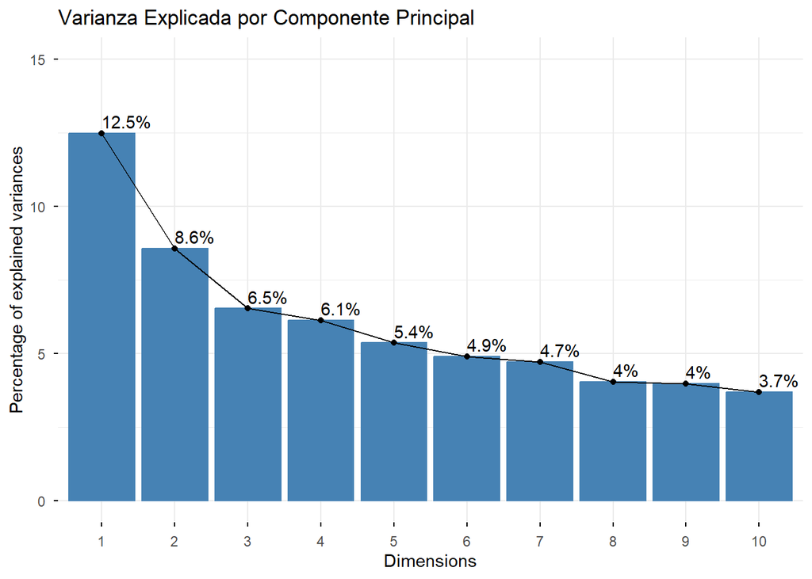

```r
fviz_eig(pca, addlabels = TRUE, ylim = c(0, 15),
         barfill = "steelblue", barcolor = "steelblue",
         title = "Varianza Explicada por Componente Principal")
```

Tanto en la tabla como en el gráfico de barras, podemos observar que los PCs no parecen explicar mucha varianza de los datos de manera individual (el PC1 explica el 12.5% de la varianza, el PC2 el 8.6%, y así sucesivamente). Si queremos usarlos estos PCs en análisis posteriores, habrá que considerar seleccionar un número alto de los mismos para que representen bien a las 37 variables de expresión genética.

Podemos extraer los scores de los primeros seis PCs, y añadirlos a nuestro data frame con todos los datos.

```r
scores <- as.data.frame(pca$x[,1:6])
colnames(scores) <- paste0("PC",1:6)
df_pca <- bind_cols(df_clean, scores)
```

# Paso 4: Visualizaciones

Podemos generar un biplot (gráficas que comparan los valores de pares de PCs) con `fviz_pca_biplot()`.

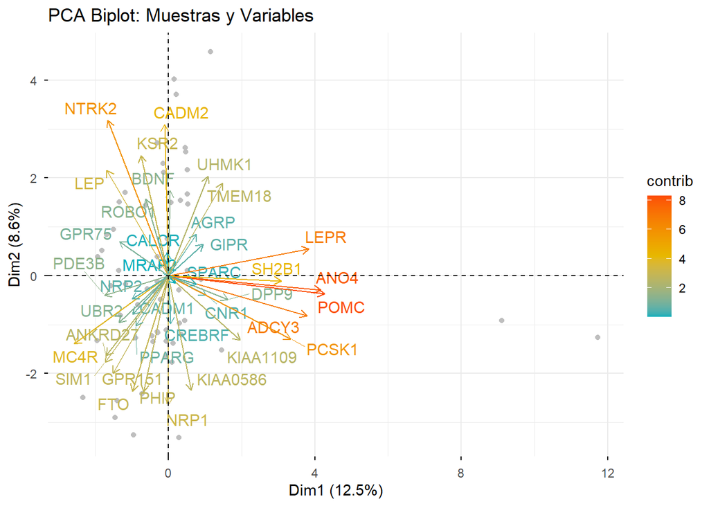

```r
fviz_pca_biplot(pca,
                geom.ind = "point", # Solo puntos para las muestras
                col.ind = "grey",    # Color de las muestras
                col.var = "contrib", # Color de variables según su contribución
                gradient.cols = c("#00AFBB", "#E7B800", "#FC4E07"),
                repel = TRUE,        # Evita solapamiento de texto
                title = "PCA Biplot: Muestras y Variables")
```

En esta figura, el color y la longitud de las flechas indican la contribución de cada gen a la variabilidad total. Los genes que más importancia tienen, como ANO4, POMC, LEPR y ADCY3, toman colores cálidos (naranja y rojo) y presentan flechas más largas. Esto significa su relación con los grupos de muestrasa lo largo del eje de ese PC (eje y muestras perpendiculares: independencia; eje y muestras paralelas en mismo sentido: correlación positiva; eje y muestras paralelas en distinto sentido: correlación negativa). Podemos observar dos puntos claramente alejados hacia la derecha: estas muestras presentan un perfil de expresión distinto al resto.

Podemos representar visualmente la calidad de la representación de cada variable graficando la variable `cos2` del análisis PCA con la función `fviz_pca_var()`.

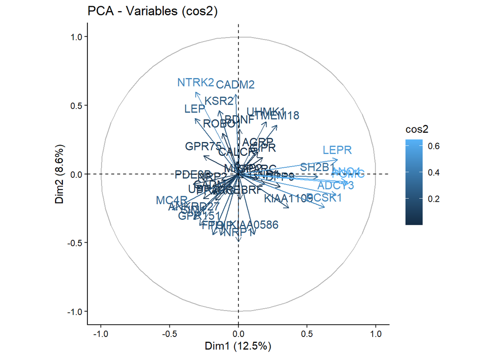

```r
fviz_pca_var(pca, col.var="cos2") +
  ggtitle("PCA - Variables (cos2)") +
  theme_classic()
```

De manera similar al biplot anterior, ANO4, POMC, LEPR y ADCY3 parecen ser las que mejores valores de calidad de representación poseen, estando más relacionadas con el PC1, el que más varianza explica de los datos. Los genes en el centro (flechas cortas y color azul oscuro) no están bien representados por estos dos PCs.

A continuación, analizamos con clustering jerárquico las muestras de individuos, agrupándolos en 3 clusters, basándonos en los seis primeros PCs del PCA. Primero debemos generar una matriz de distancias euclidianas a partir de los los PCs del 1 al 6 de PCA, que se encuentran en `df_pca`, usando la función `dist()` con la opción `method = "euclidean"`. A continuación, realizamos el clustering jerárquico con el método completo usando la función `hclust()` y la opción `method = "complete"`.

```r
hc_pcs <- df_pca %>%
          select(PC1:PC6) %>%
          dist(method = "euclidean") %>%
          hclust(method = "complete")
```

Ahora podemos visualizar el dendrograma resultante con la función `fviz_dend()`, organizándolo en 3 clusters diferentes con la opción `k = 3`.

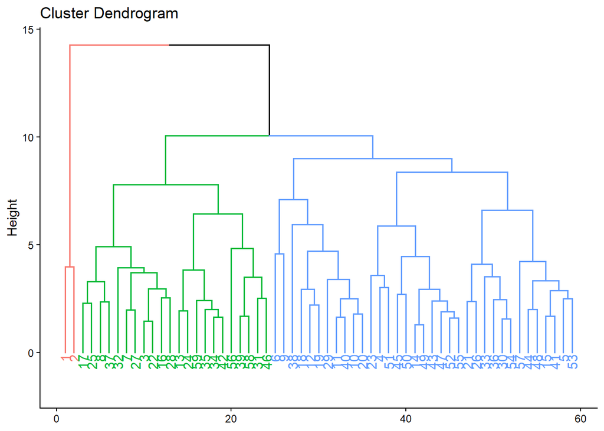

```r
fviz_dend(hc_pcs,
          k = 3,
          color_labesls_by_k = TRUE) +
  theme_classic()
```

Viendo el dendrograma, las muestras 1 y 2 se desmarcan del resto, como se ve en el PCA. El resto de muestras se organizan en dos clusters más grandes, pero el PCA no parece discriminarlos dada la relativamente poca varianza explicada de cada PC (el PC1, que es el que más varianza explica, muestra solo un 12.5% de varianza de la expresión de los 37 genes).

Para cada PC, podemos comprobar la contribución de cada variable con la función `fiz_contrib()`. Por ejemplo, para comprobar qué variables contruibuyen más a la varianza explicada por el PC1, podemos ejecutar:

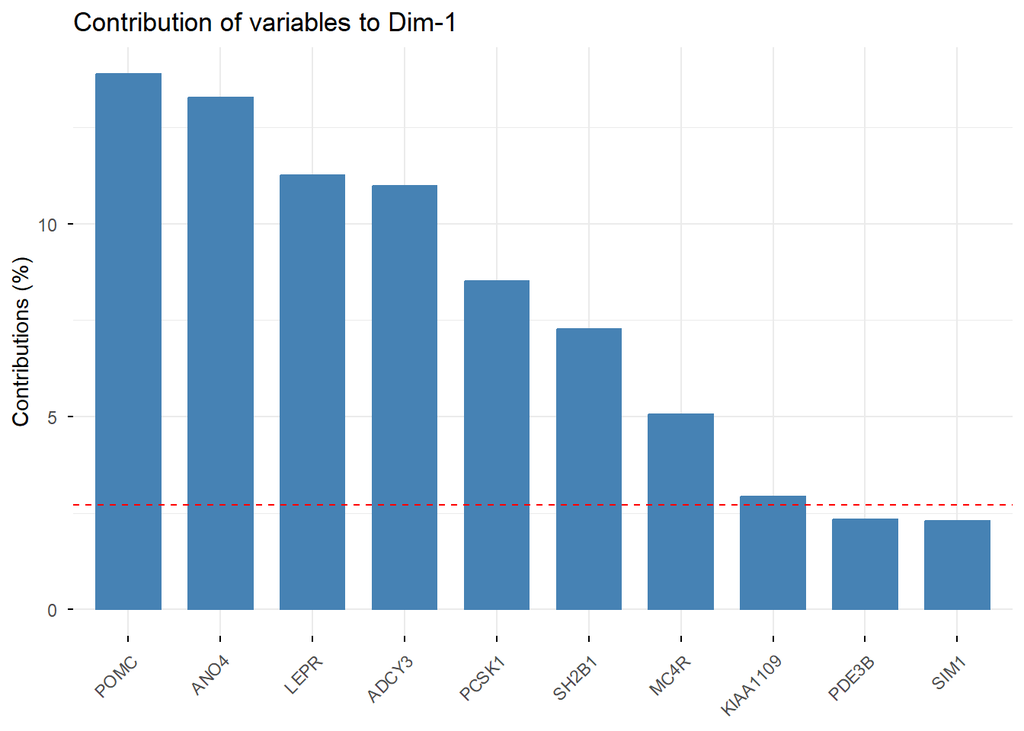

```r
fviz_contrib(pca, choice = "var", axes = 1, top = 10)
```

Este gráfico de barras cuantifica qué genes son los “motores” que mueven las muestras a lo largo del eje X. Los Genes POMC, ANO4, LEPR y ADCY3 son los que más contribuyen. Superan la línea roja discontinua (contribución media esperada), por lo que son los biomarcadores más importantes para diferenciar a los individuos en el PC1.

Ahora comprobaremos cómo se distribuyen las muestras en el PCA y el análisis cluster en función de la variable índice de masa corporal (IMC), que se encuentra en el data frame como `imc_kg_m2`. Para que visualmente sea esta variable interpretable, haremos que esté dividida en tres categorías: normal, sobrepeso, y obesidad, que se correspondan con el primer, segundo y tercer tercil, respectivamente, de la distribución de la variable `imc_kg_m2`. Primero, generamos una función para calcular terciles y etiquetarlos como los niveles predichos. Primero calculará los terciles con la función `quantile()`, y a continuación establecerá las tres categorías basadas en terciles con el comando `cut()`.

```r
terciles_obesos <- function(x){
  q <- quantile(x, probs = c(1/3, 2/3))
  cut(x, breaks = c(-Inf, q, Inf),
      labels = c("Normal", "Sobrepeso","Obesidad"))
}
```

Una vez cargada la función, la aplicamos a la variable numérica `imc_kg_m2` en nuestro data frame, generando la variable categórica `pesoTipo`.

```r
df_clean$pesoTipo <- terciles_obesos(df_clean$imc_kg_m2)
```

Graficamos los individuos (pacientes) en el espacio de las primeras dos componentes coloreados por categoría de IMC (Normal, Sobrepeso, Obesidad) con la función `fviz_pca_biplot`, usando la variable categórica `pesoTipo` para colorear las muestras.

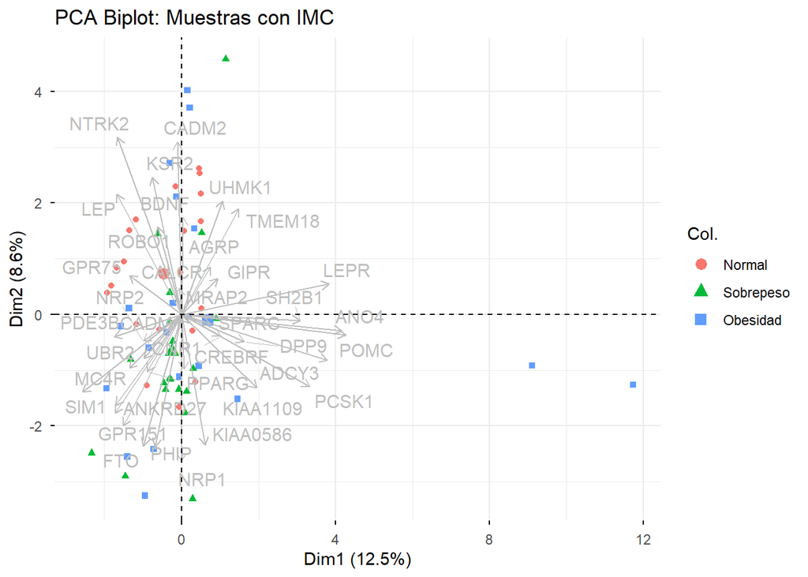

```r
fviz_pca_biplot(pca,
                geom.ind = "point",
                col.ind = df_clean$pesoTipo,
                col.var = "grey",
                repel = TRUE,
                title = "PCA Biplot: Muestras con IMC")
```

Observamos que las dos muestras atípicas son de la categoría obesa, y que se relacionan con los genes ANO4 y POMC, cuyas flechas en el biplot apuntan casi directamente a estas muestras. Esperamos que los valores de expresión de estos dos genes sean de los más altos enestas dos muestras.

De nuevo analizamos con clustering jerárquico las muestras agrupándolas en 3 clusters, esta vez basándonos en sus scores de PCA. Primero debemos generar una matriz de distancias euclidianas a partir de los scores de PCA, que se encuentran en `pca$x` generado por `prcomp()`. El resto se hace igual que en el gráfico anterior: usamos `dist()` con la opción `method = "euclidean"` para generar la matriz de distancias, y `hclust()` con la opción `method = "complete"` para el clustering jerárquico.

```r
hc_scores <- hclust(dist(pca$x, method = "euclidean"), method = "complete")

hc_scores <- pca$x %>%
             dist(method = "euclidean") %>%
             hclust(method = "complete")
```

Visualizamos el dendrograma resultante con `fviz_dend()`, especificando `k = 3`.

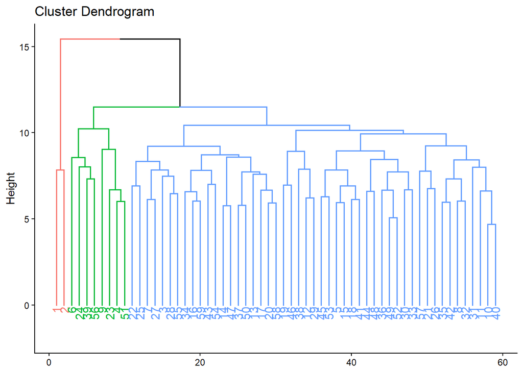

```r
fviz_dend(hc_scores,
          k = 3,
          color_labesls_by_k = TRUE) +
  theme_classic()
```

De nuevo, las muestras 1 y 2 se desmarcan del resto. El resto de muestras se organizan en dos clusters más grandes, como en el dendrograma anterior, pero esta vez el cluster verde incluye menos muestras.

Podemos concluir que, ya sea con dimiensiones reducidas, o con los datos escalados y centrados del PCA, es consistente que los individuos 1 y 2 presentan una expresión genética particular dentro de la categoría obeso.

# Paso 5 - Heatmap

Para generar un heatmap entre los seis primeros PCs y las variables de expresión de genes, primero generamos una matriz de correlaciones con la función `cor()`, especificando que usaremos el coeficiente de Spearman con la opción `method="spearman"`.

```r
cors <- cor(df_pca %>% select (ADCY3:UHMK1),
            df_pca %>% select(PC1:PC6),
            method="spearman", use = "pairwise.complete.obs")
```

Ahora, generamos el heatmap a partir de la matriz de correlaciones generada, usando la función `pheatmap()`.

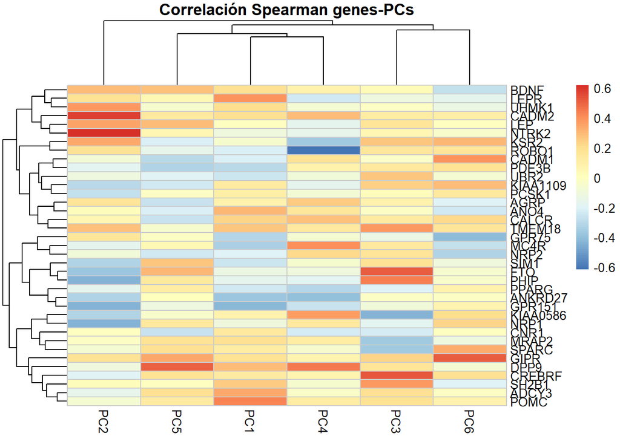

```r
pheatmap(cors,
         border_color = "grey80",
         main="Correlación Spearman genes-PCs")
```

El clustering con los datos de expresión de genes nos permite identificar grupos con patrones de correlación similares a lo largo de los componentes principales.

Para realizar un heatmap de la expresión génica estandarizada, primero organizaremos los datos en una matriz para su correcta visualización y una vez organizados se estandariza con la función `scale`.

```r
mat <- df_clean %>%
  select(ADCY3:UHMK1) %>%
  as.matrix()

mat_z <- scale (mat) #estandarización
```

Visualizamos el heatmap con los valores estandardizados de expresión, de nuevo, con `pheatmap`. Este heatmap se ordenó mediante clustering jerárquico, utilizando el método de distancia euclídea y el método de enlace completo, con el fin de agrupar individuos y genes con perfiles de expresión similares (en este caso, que presenten patrones coordinados de sobre- e infra-expresión).

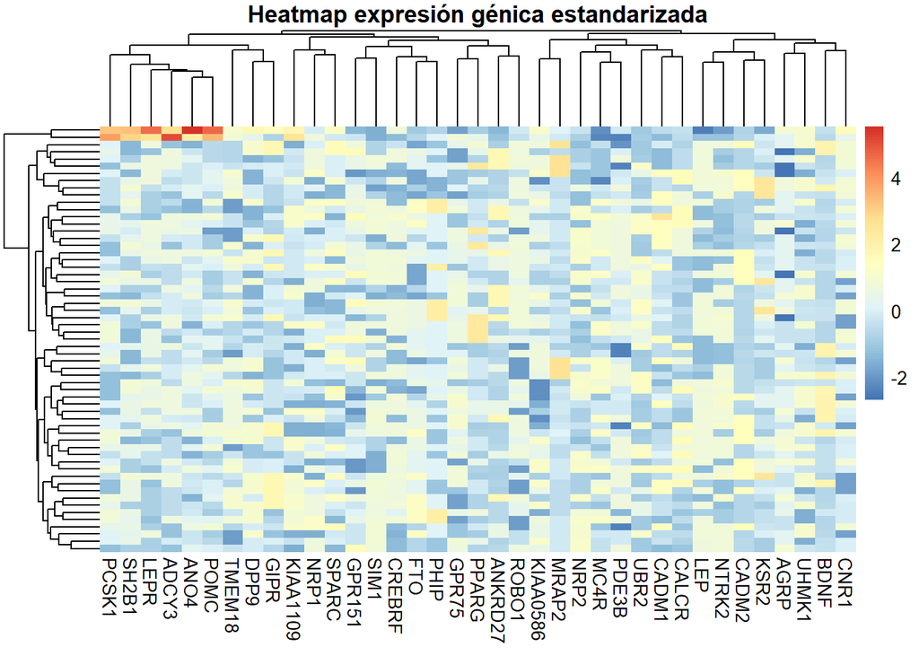

```r
pheatmap(mat_z,
  border_color = NA,
  clustering_method = "complete",
  clustering_distance_rows = "euclidean",
  clustering_distance_cols = "euclidean",
  main = "Heatmap expresión génica estandarizada")
```

El heatmap de expresión génica estandarizada permite visualizar patrones de coexpresión y diferencias entre los individuos analizados. Este análisis exploratorio mostró la existencia de grupos de genes con comportamientos similares.

De forma complementaria, el heatmap de correlaciones Spearman entre genes y los seis primeros PCs ayudó a interpretar el PCA, identificando qué genes contribuyen a cada componente. En conjunto, ambos heatmaps muestran coherencia entre los patrones de expresión observados y la estructura capturada por el análisis de componentes principales.

# Paso 6 - Tablas descriptivas

Primero calculamos los percentiles para dividir los datos en tres grupos iguales.

```r
make_terciles <- function(x){
  q <- quantile(x, probs=c(1/3,2/3))
  cut(x, breaks=c(-Inf,q,Inf), labels=c("t1","t2","t3"))
}
```

Creamos las variables de Componentes Principales divididas en terciles.

```r
df_pca <- df_pca %>%
  mutate(
    PC1_t = make_terciles(PC1),
    PC2_t = make_terciles(PC2),
    PC3_t = make_terciles(PC3)
  )
```

Para representar tablas descriptivas, al no seguir los valores de expresión de genes una distribución normal, empleamos los estadísticos de mediana y rango intercuartílico. Además, establecemos el rango de genes.

```r
stats <- list(all_continuous()~"{median} ({p25}, {p75})")
genes_cols <- df_pca %>% select(ADCY3:UHMK1) %>% names()
```

Generamos las tablas individuales por cada Componente Principal. Forzamos el tipo ‘continuous’ para el rango de genes porque detecta valores con muchos decimales o muestras pequeñas como variables categóricas y no como numéricas.

```r
# Componente Principal 1
tabla_pc1 <- df_pca %>%
  select(PC1_t, all_of(genes_cols)) %>%
  tbl_summary(
    by = PC1_t,
    type = list(all_of(genes_cols) ~ "continuous"),
    statistic = stats,
    digits = all_continuous() ~ 1
  ) %>%
  add_p(
    test = all_continuous() ~ "kruskal.test",
    pvalue_fun = ~ style_pvalue(.x, digits = 3)
  )

# Componente Principal 2
tabla_pc2 <- df_pca %>%
  select(PC2_t, all_of(genes_cols)) %>%
  tbl_summary(
    by = PC2_t,
    type = list(all_of(genes_cols) ~ "continuous"),
    statistic = stats,
    digits = all_continuous() ~ 1
  ) %>%
  add_p(
    test = all_continuous() ~ "kruskal.test",
    pvalue_fun = ~ style_pvalue(.x, digits = 3)
  )

# Componente Principal 3
tabla_pc3 <- df_pca %>%
  select(PC3_t, all_of(genes_cols)) %>%
  tbl_summary(
    by = PC3_t,
    type = list(all_of(genes_cols) ~ "continuous"),
    statistic = stats,
    digits = all_continuous() ~ 1
  ) %>%
  add_p(
    test = all_continuous() ~ "kruskal.test",
    pvalue_fun = ~ style_pvalue(.x, digits = 3)
  )
```

Unimos las tablas descriptivas de todos los PC.

```r
tbl_merge(
  tbls = list(tabla_pc1, tabla_pc2, tabla_pc3),
  tab_spanner = c("**PC1**", "**PC2**", "**PC3**")
)
```

| **Characteristic** | **PC1** **t1** N = 20<sup>1</sup> | **PC1** **t2** N = 19<sup>1</sup> | **PC1** **t3** N = 20<sup>1</sup> | **PC1** **p-value**<sup>2</sup> | **PC2** **t1** N = 20<sup>1</sup> | **PC2** **t2** N = 19<sup>1</sup> | **PC2** **t3** N = 20<sup>1</sup> | **PC2** **p-value**<sup>2</sup> | **PC3** **t1** N = 20<sup>1</sup> | **PC3** **t2** N = 19<sup>1</sup> | **PC3** **t3** N = 20<sup>1</sup> | **PC3** **p-value**<sup>2</sup> |
| --- | --- | --- | --- | --- | --- | --- | --- | --- | --- | --- | --- | --- |
| ADCY3 | -0.8 (-0.9, -0.5) | -0.5 (-0.8, -0.2) | -0.2 (-0.8, -0.2) | 0.016 | -0.2 (-0.8, -0.2) | -0.5 (-0.8, -0.2) | -0.5 (-0.8, -0.2) | 0.490 | -0.5 (-0.9, -0.4) | -0.5 (-0.8, -0.2) | -0.4 (-0.8, -0.2) | 0.351 |
| AGRP | 0.2 (-0.2, 0.5) | 0.2 (-0.2, 0.3) | 0.2 (-0.2, 0.7) | 0.707 | 0.2 (-0.2, 0.3) | 0.2 (0.2, 0.3) | 0.2 (0.0, 0.7) | 0.550 | 0.2 (-0.2, 0.6) | 0.3 (0.2, 0.7) | 0.2 (-0.2, 0.5) | 0.657 |
| ANKRD27 | 0.8 (-0.2, 0.8) | -0.2 (-0.4, 2.1) | -0.4 (-0.4, -0.2) | 0.046 | 0.3 (-0.2, 2.1) | 0.8 (-0.4, 0.8) | -0.4 (-0.4, -0.2) | 0.040 | -0.2 (-0.4, 1.5) | -0.2 (-0.4, 0.8) | -0.2 (-0.4, 2.1) | 0.719 |
| ANO4 | -0.5 (-0.8, -0.3) | -0.5 (-0.5, -0.3) | -0.3 (-0.5, -0.2) | 0.208 | -0.5 (-0.5, -0.3) | -0.3 (-0.5, -0.1) | -0.5 (-0.5, -0.3) | 0.117 | -0.5 (-0.5, -0.3) | -0.3 (-0.5, -0.2) | -0.5 (-0.5, -0.2) | 0.861 |
| BDNF | -0.8 (-0.9, -0.7) | -0.8 (-0.9, -0.7) | -0.7 (-0.8, 1.2) | 0.208 | -0.8 (-0.9, -0.7) | -0.7 (-0.9, -0.7) | -0.7 (-0.8, 1.2) | 0.154 | -0.8 (-0.9, 0.3) | -0.7 (-0.8, 1.2) | -0.8 (-0.9, -0.7) | 0.587 |
| CADM1 | -0.4 (-0.6, 1.0) | -0.1 (-0.6, 1.0) | -0.6 (-0.9, -0.4) | 0.029 | -0.2 (-0.6, 1.0) | -0.4 (-0.6, 1.0) | -0.4 (-0.6, -0.3) | 0.512 | -0.5 (-0.9, 1.0) | -0.4 (-0.6, 1.0) | -0.4 (-0.6, -0.1) | 0.507 |
| CADM2 | -0.7 (-0.7, -0.6) | -0.7 (-0.7, 1.2) | -0.6 (-0.7, 1.2) | 0.367 | -0.7 (-0.8, -0.7) | -0.7 (-0.7, 1.2) | 1.2 (-0.6, 1.2) | <0.001 | -0.6 (-0.7, -0.6) | -0.7 (-0.7, 1.2) | -0.6 (-0.7, 1.2) | 0.399 |
| CALCR | -0.3 (-1.0, 1.0) | -0.3 (-0.7, 1.0) | -0.2 (-0.3, 1.5) | 0.308 | -0.3 (-0.8, 1.5) | -0.3 (-0.7, 1.0) | 0.4 (-0.6, 1.5) | 0.337 | -0.3 (-0.8, 1.0) | -0.3 (-0.6, 2.0) | -0.3 (-0.7, 1.0) | 0.441 |
| CNR1 | -0.2 (-0.3, 0.7) | -0.2 (-1.9, 0.7) | -0.2 (-0.3, 0.7) | 0.667 | -0.2 (-0.3, 0.7) | -0.2 (-0.3, 0.7) | -0.2 (-1.1, 0.7) | 0.996 | 0.7 (-0.3, 0.7) | -0.2 (-0.3, 0.7) | -0.3 (-1.9, 0.7) | 0.151 |
| CREBRF | 0.4 (-1.4, 0.7) | 0.6 (-1.4, 0.7) | 0.7 (-1.4, 0.8) | 0.322 | 0.7 (0.4, 0.8) | 0.6 (-1.4, 0.7) | 0.1 (-1.4, 0.8) | 0.316 | -1.4 (-1.4, 0.7) | 0.6 (-1.4, 0.7) | 0.7 (0.6, 0.8) | 0.001 |
| DPP9 | -1.2 (-1.5, -0.2) | 0.7 (-0.3, 0.8) | -0.1 (-0.7, 0.8) | 0.025 | 0.3 (-0.7, 0.8) | -0.3 (-1.2, 0.7) | -0.3 (-1.2, 0.8) | 0.302 | -0.3 (-1.5, 0.8) | -0.3 (-1.2, 0.7) | 0.7 (-0.7, 0.8) | 0.369 |
| FTO | 0.6 (0.2, 0.9) | 0.6 (-0.3, 0.9) | 0.6 (-0.4, 0.9) | 0.756 | 0.9 (0.6, 1.7) | 0.6 (-0.3, 0.9) | -0.3 (-1.4, 0.9) | 0.025 | 0.6 (-0.3, 0.6) | 0.6 (-1.4, 0.9) | 0.9 (0.8, 1.7) | <0.001 |
| GIPR | -0.4 (-0.8, 0.0) | 0.0 (-0.2, 1.6) | -0.2 (-0.6, 0.7) | 0.042 | -0.2 (-0.6, 1.5) | -0.2 (-1.0, 0.0) | -0.2 (-0.2, 0.0) | 0.402 | -0.2 (-0.6, 0.0) | -0.2 (-0.6, 0.0) | 0.0 (-0.4, 1.6) | 0.128 |
| GPR151 | 0.4 (0.0, 0.7) | 0.5 (-0.2, 0.7) | -0.2 (-1.2, 0.2) | 0.008 | 0.6 (0.3, 1.0) | -0.2 (-1.2, 0.5) | -0.2 (-0.7, 0.4) | 0.002 | 0.3 (-0.2, 0.7) | 0.1 (-1.2, 0.5) | 0.2 (-0.2, 0.6) | 0.481 |
| GPR75 | 0.6 (0.3, 0.7) | 0.3 (-1.1, 0.7) | 0.1 (-1.5, 0.5) | 0.090 | 0.3 (-1.5, 0.6) | 0.4 (-1.1, 0.7) | 0.4 (-0.5, 0.7) | 0.513 | 0.5 (-0.5, 0.6) | 0.4 (-1.1, 0.7) | 0.2 (-1.1, 0.6) | 0.498 |
| KIAA0586 | 0.5 (-0.5, 0.8) | 0.7 (-0.5, 0.9) | 0.7 (-0.5, 0.9) | 0.822 | 0.8 (0.5, 0.9) | 0.7 (0.5, 0.9) | -0.5 (-1.4, 0.8) | 0.053 | 0.9 (0.6, 0.9) | 0.5 (-0.5, 0.9) | 0.3 (-0.5, 0.7) | 0.019 |
| KIAA1109 | -0.5 (-0.7, 0.4) | -0.5 (-0.7, 0.3) | -0.5 (-0.7, 0.4) | 0.830 | -0.1 (-0.5, 0.4) | -0.5 (-0.7, 0.3) | -0.6 (-1.6, -0.1) | 0.028 | -0.5 (-1.1, -0.5) | -0.5 (-0.7, 0.4) | -0.1 (-0.7, 0.4) | 0.250 |
| KSR2 | -0.2 (-0.6, 0.2) | 0.0 (-0.4, 0.6) | -0.2 (-0.8, 0.2) | 0.570 | -0.4 (-0.8, 0.1) | -0.2 (-0.4, 0.0) | 0.2 (-0.4, 2.0) | 0.041 | -0.3 (-0.8, -0.2) | 0.0 (-0.2, 0.6) | 0.0 (-0.4, 0.6) | 0.027 |
| LEP | 1.0 (-0.5, 1.1) | 1.0 (-0.7, 1.1) | 1.0 (0.4, 1.1) | 0.393 | -0.3 (-0.7, 1.1) | 1.0 (-0.7, 1.1) | 1.0 (1.0, 1.1) | 0.022 | 1.0 (-0.7, 1.1) | 1.0 (-0.3, 1.1) | 1.0 (-0.5, 1.1) | 0.525 |
| LEPR | -0.9 (-0.9, -0.2) | -0.2 (-0.9, 0.0) | -0.2 (-0.7, 0.0) | 0.057 | -0.8 (-0.9, -0.2) | -0.2 (-0.9, 0.0) | -0.2 (-0.9, 0.0) | 0.399 | -0.2 (-0.9, 0.0) | -0.7 (-0.9, 0.0) | -0.4 (-0.9, -0.2) | 0.778 |
| MC4R | 0.5 (0.0, 1.2) | 0.1 (0.0, 0.9) | -0.5 (-0.5, 0.5) | 0.039 | 0.9 (-0.2, 1.1) | 0.1 (0.0, 1.2) | 0.1 (-0.2, 0.9) | 0.771 | 0.0 (-0.5, 0.9) | 0.1 (0.0, 1.2) | 0.5 (0.0, 1.1) | 0.443 |
| MRAP2 | -0.2 (-0.5, -0.2) | -0.2 (-0.5, -0.2) | -0.2 (-0.3, -0.1) | 0.246 | -0.2 (-0.5, -0.2) | -0.2 (-0.5, -0.2) | -0.3 (-0.5, -0.2) | 0.884 | -0.2 (-0.4, 2.4) | -0.2 (-0.5, -0.2) | -0.3 (-0.5, -0.2) | 0.070 |
| NRP1 | 0.7 (0.0, 0.8) | 0.0 (0.0, 0.7) | 0.0 (-1.6, 1.0) | 0.674 | 0.7 (0.0, 1.3) | 0.7 (0.0, 0.8) | -1.2 (-1.6, 0.4) | 0.009 | 0.3 (0.0, 0.8) | 0.2 (-1.6, 1.3) | 0.0 (-1.4, 0.7) | 0.454 |
| NRP2 | 0.9 (-1.2, 0.9) | -0.6 (-1.7, 0.9) | -0.9 (-1.2, 0.5) | 0.326 | -0.6 (-1.4, 0.9) | -0.6 (-1.2, 0.9) | -0.1 (-1.4, 0.9) | 0.914 | -0.9 (-1.4, 0.9) | -0.6 (-1.2, 0.9) | 0.8 (-1.2, 0.9) | 0.399 |
| NTRK2 | 1.1 (-0.4, 1.1) | -0.4 (-0.6, 1.3) | 1.1 (-0.6, 1.1) | 0.943 | -0.4 (-0.6, -0.4) | 1.1 (-0.6, 1.1) | 1.1 (1.1, 1.3) | <0.001 | 1.1 (-0.5, 1.1) | 1.1 (-0.4, 1.1) | -0.4 (-0.6, 1.3) | 0.907 |
| PCSK1 | -0.5 (-1.2, -0.1) | -0.5 (-1.2, 0.0) | -0.5 (-0.7, -0.3) | 0.871 | -0.3 (-0.6, 0.0) | -0.5 (-1.2, -0.3) | -0.6 (-1.2, -0.5) | 0.050 | -0.5 (-1.0, -0.3) | -0.5 (-0.7, -0.2) | -0.5 (-1.2, 0.0) | 0.956 |
| PDE3B | 0.9 (0.3, 0.9) | 0.3 (0.2, 0.9) | 0.2 (-0.6, 0.9) | 0.089 | 0.9 (0.2, 0.9) | 0.9 (0.2, 0.9) | 0.3 (0.2, 0.9) | 0.448 | 0.6 (-0.5, 0.9) | 0.9 (0.2, 0.9) | 0.3 (0.2, 0.9) | 0.900 |
| PHIP | 0.1 (-0.9, 1.1) | 0.1 (-0.9, 0.1) | 0.1 (-0.2, 0.1) | 0.518 | 0.1 (0.1, 1.1) | 0.1 (-0.9, 0.1) | -0.2 (-0.9, 0.1) | 0.019 | 0.1 (-0.9, 0.1) | 0.1 (-0.9, 0.1) | 0.1 (0.1, 2.0) | 0.002 |
| POMC | -0.6 (-0.7, -0.3) | -0.3 (-0.6, -0.2) | -0.2 (-0.6, 0.1) | 0.010 | -0.3 (-0.6, -0.2) | -0.3 (-0.7, 0.1) | -0.3 (-0.6, -0.2) | 0.864 | -0.6 (-0.7, -0.2) | -0.3 (-0.7, 0.1) | -0.3 (-0.6, -0.1) | 0.283 |
| PPARG | -0.4 (-0.8, 1.2) | -0.4 (-1.0, 0.1) | -1.0 (-1.1, -0.4) | 0.064 | -0.4 (-1.0, 0.3) | -0.4 (-1.0, 0.1) | -0.7 (-1.1, -0.2) | 0.258 | -0.4 (-1.0, 0.4) | -0.4 (-1.0, 0.1) | -0.4 (-1.0, -0.2) | 0.510 |
| ROBO1 | 0.6 (-0.5, 0.7) | 0.6 (0.2, 0.8) | 0.2 (-1.3, 0.6) | 0.158 | 0.4 (-1.3, 0.7) | -0.5 (-2.2, 0.8) | 0.6 (0.2, 0.6) | 0.401 | 0.4 (-1.3, 0.8) | 0.2 (-0.5, 0.6) | 0.6 (0.2, 0.8) | 0.527 |
| SH2B1 | -0.3 (-1.1, -0.1) | -0.2 (-0.9, -0.1) | -0.2 (-0.9, 0.0) | 0.317 | -0.2 (-0.9, -0.1) | -0.2 (-0.9, -0.1) | -0.2 (-0.9, 0.0) | 0.917 | -1.1 (-1.3, -0.2) | -0.1 (-0.2, 0.1) | -0.2 (-0.9, -0.1) | <0.001 |
| SIM1 | 1.2 (0.4, 1.2) | 1.0 (-0.2, 1.2) | 0.4 (-0.6, 1.2) | 0.144 | 1.2 (0.4, 1.2) | 1.0 (-0.2, 1.2) | 0.4 (-0.7, 1.2) | 0.155 | -0.2 (-0.2, 1.2) | 1.0 (-0.9, 1.2) | 1.2 (1.0, 1.2) | 0.310 |
| SPARC | -0.1 (-0.3, 0.0) | 0.0 (-1.2, 1.1) | 0.0 (-0.7, 0.9) | 0.687 | 0.0 (-0.3, 1.1) | 0.0 (-0.2, 0.8) | -0.3 (-1.2, 0.8) | 0.195 | 0.0 (-0.1, 0.9) | 0.0 (-0.2, 0.8) | -0.3 (-1.2, 0.4) | 0.050 |
| TMEM18 | -0.3 (-1.3, 0.2) | 0.7 (-0.3, 1.0) | 0.6 (-0.4, 0.8) | 0.030 | -0.3 (-0.7, 0.9) | -0.2 (-0.7, 0.8) | 0.7 (-0.3, 0.8) | 0.179 | -0.7 (-0.7, 0.7) | 0.6 (-0.7, 0.7) | 0.8 (-0.3, 1.0) | 0.014 |
| UBR2 | 0.7 (-0.7, 1.3) | 0.7 (-0.7, 1.5) | -0.7 (-0.7, 0.7) | 0.116 | 0.7 (-0.7, 1.3) | 0.7 (-0.7, 1.3) | -0.7 (-0.7, 1.3) | 0.664 | -0.7 (-0.7, 0.7) | 0.7 (-0.7, 1.3) | 0.7 (-0.7, 1.5) | 0.190 |
| UHMK1 | -0.6 (-0.7, 0.7) | -0.7 (-2.0, -0.6) | 0.7 (-0.6, 0.7) | 0.022 | -0.7 (-2.0, 0.0) | -0.6 (-0.7, 0.7) | 0.7 (-0.6, 0.7) | 0.032 | -0.6 (-1.4, 0.7) | 0.7 (-0.7, 0.7) | -0.7 (-1.4, 0.7) | 0.309 |

<sup>1</sup> Median (Q1, Q3)  
<sup>2</sup> Kruskal-Wallis rank sum test

EXPLICACIÓN DE RESULTADOS: PC1: Destacan los incrementos de expresión en ADCY3 y POMC, junto con una caída relevante en GPR151 hacia el tercer tercil. PC2: Presenta las variaciones más extremas de la tabla, con saltos drásticos de niveles negativos a positivos en CADM2 y NTRK2. PC3: Los cambios más potentes ocurren en SH2B1, que sube desde valores mínimos , y en FTO, que muestra un ascenso marcado en el último grupo o tercer tercil.

# Paso 7: Regresión Logística

Construiremos un modelo de regresióno logística mediante la función `glm`, donde la variable dependiente es si el individuo presenta normopeso u obesidad, y las variables predictoras son los terciles de los componentes principales obtenidos en el PCA, además de escoger otras variables que pueden ser relevantes como el sexo y la edad.

Primero, definimos una función para determinar si un individuo es normal u obeso.

```r
clinico_obesos <- function(x) {
  cut(x,
      breaks = c(-Inf, 29.99, Inf),
      labels = c("Normopeso", "Obesidad"))
}
```

Aplicamos la función al data frame del modelo (usamos el data frame `df_pca`)

```r
df_pca$pesoClinico <- clinico_obesos(df_pca$imc_kg_m2)
table(df_pca$pesoClinico)
```

```
##
## Normopeso  Obesidad
##        52         7
```

Modificamos las variables a analizar del data frame con `mutate`.

```r
df_pca <- df_pca %>%
  mutate(
    pesoClinico = factor(pesoClinico, levels = c("Normopeso", "Obesidad")),
    pesoClinico = relevel(pesoClinico, ref = "Normopeso"),
    PC1_t = relevel(factor(PC1_t), ref = "t1"),
    PC2_t = relevel(factor(PC2_t), ref = "t1"),
    PC3_t = relevel(factor(PC3_t), ref = "t1")
  )
```

Nos aseguramos que la variable `pesoClinico` es un factor (necesario para analizarlo con la familia binomial).

```r
df_pca$pesoClinico <- as.factor(df_pca$pesoClinico)
```

Nos aseguramos también de que cada variable potencial a analizar sea de la clase correcta.

```r
df_pca$edad_anios <- as.numeric(as.character(df_pca$edad_anios))
df_pca$sexo <- as.factor(df_pca$sexo)
```

Generamos el modelo logístico.

```r
modelo_log <- glm(
  pesoClinico ~ PC1_t + PC2_t + PC3_t + edad_anios + sexo,
  data = df_pca,
  family = binomial)
```

Observamos los resultados.

```r
summary(modelo_log)            # resumen del modelo (coeficientes y error estandar)
```

```
##
## Call:
## glm(formula = pesoClinico ~ PC1_t + PC2_t + PC3_t + edad_anios +
##     sexo, family = binomial, data = df_pca)
##
## Coefficients:
##               Estimate Std. Error z value Pr(>|z|)
## (Intercept)   -3.66782    2.36459  -1.551    0.121
## PC1_tt2       -0.54909    1.33118  -0.412    0.680
## PC1_tt3        1.21300    1.07128   1.132    0.258
## PC2_tt2       -1.77258    1.39888  -1.267    0.205
## PC2_tt3       -0.22749    1.24695  -0.182    0.855
## PC3_tt2        1.47007    1.27119   1.156    0.247
## PC3_tt3        0.02397    1.41425   0.017    0.986
## edad_anios     0.02120    0.02402   0.882    0.378
## sexoMasculino  0.24664    1.38270   0.178    0.858
##
## (Dispersion parameter for binomial family taken to be 1)
##
##     Null deviance: 42.977  on 58  degrees of freedom
## Residual deviance: 35.899  on 50  degrees of freedom
## AIC: 53.899
##
## Number of Fisher Scoring iterations: 6
```

```r
confint(modelo_log)    # intervalos confianza coeficientes
```

```
##                     2.5 %     97.5 %
## (Intercept)   -8.87744600 0.57956246
## PC1_tt2       -3.74687596 2.01191163
## PC1_tt3       -0.77684504 3.57823455
## PC2_tt2       -5.13361637 0.73694881
## PC2_tt3       -3.04683543 2.14434704
## PC3_tt2       -0.80317760 4.62649362
## PC3_tt3       -2.78749491 3.30144999
## edad_anios    -0.02605529 0.07109753
## sexoMasculino -2.59279407 3.04499532
```

```r
exp(coef(modelo_log))          # Odds Ratios para cada categoría frente a la de referencia
```

```
##   (Intercept)       PC1_tt2       PC1_tt3       PC2_tt2       PC2_tt3
##    0.02553196    0.57747255    3.36356716    0.16989451    0.79653203
##       PC3_tt2       PC3_tt3    edad_anios sexoMasculino
##    4.34954452    1.02425453    1.02142261    1.27972096
```

```r
exp(confint(modelo_log))    # Intervalos de confianza de las Odds Ratios
```

```
##                     2.5 %     97.5 %
## (Intercept)   0.000139500   1.785257
## PC1_tt2       0.023591331   7.477598
## PC1_tt3       0.459854550  35.810264
## PC2_tt2       0.005895203   2.089550
## PC2_tt3       0.047509032   8.536465
## PC3_tt2       0.447903442 102.155240
## PC3_tt3       0.061575273  27.151980
## edad_anios    0.974281218   1.073686
## sexoMasculino 0.074810721  21.009933
```

Generamos la tabla de resultados.

```r
tabla_resultados <- exp(cbind(OR = coef(modelo_log), confint(modelo_log)))
print(tabla_resultados)
```

```
##                       OR       2.5 %     97.5 %
## (Intercept)   0.02553196 0.000139500   1.785257
## PC1_tt2       0.57747255 0.023591331   7.477598
## PC1_tt3       3.36356716 0.459854550  35.810264
## PC2_tt2       0.16989451 0.005895203   2.089550
## PC2_tt3       0.79653203 0.047509032   8.536465
## PC3_tt2       4.34954452 0.447903442 102.155240
## PC3_tt3       1.02425453 0.061575273  27.151980
## edad_anios    1.02142261 0.974281218   1.073686
## sexoMasculino 1.27972096 0.074810721  21.009933
```

```r
tabla_resultados <- modelo_log %>%
  tbl_regression(
    exponentiate = TRUE,              # Convierte log-odds a Odds Ratio (OR)
    conf.int = TRUE,                  # Muestra intervalos de confianza
    label = list(
      PC1_t ~ "Terciles Componente 1",
      PC2_t ~ "Terciles Componente 2",
      PC3_t ~ "Terciles Componente 3",
      edad_anios ~ "Edad (años)",
      sexo ~ "Sexo"
      )
  ) %>%
  bold_labels() %>%
  italicize_levels() %>%
  add_n(location = "level") %>%       # Añade el N por cada categoría
  add_nevent(location = "level") %>%  # Añade cuántos obesos hay por categoría
    modify_header(label = "**Variable**", estimate = "**OR**") %>%
  modify_caption("**Tabla 1. Regresión Logística para Obesidad Clínica**")

tabla_resultados
```

**Tabla 1. Regresión Logística para Obesidad Clínica**

| **Variable** | **N** | **Event N** | **OR** | **95% CI** | **p-value** |
| --- | --- | --- | --- | --- | --- |
| Terciles Componente 1 |  |  |  |  |  |
| t1 | 20 | 2 | — | — |  |
| t2 | 19 | 1 | 0.58 | 0.02, 7.48 | 0.7 |
| t3 | 20 | 4 | 3.36 | 0.46, 35.8 | 0.3 |
| Terciles Componente 2 |  |  |  |  |  |
| t1 | 20 | 3 | — | — |  |
| t2 | 19 | 1 | 0.17 | 0.01, 2.09 | 0.2 |
| t3 | 20 | 3 | 0.80 | 0.05, 8.54 | 0.9 |
| Terciles Componente 3 |  |  |  |  |  |
| t1 | 20 | 1 | — | — |  |
| t2 | 19 | 4 | 4.35 | 0.45, 102 | 0.2 |
| t3 | 20 | 2 | 1.02 | 0.06, 27.2 | >0.9 |
| Edad (años) | 59 | 7 | 1.02 | 0.97, 1.07 | 0.4 |
| Sexo |  |  |  |  |  |
| Femenino | 13 | 2 | — | — |  |
| Masculino | 46 | 5 | 1.28 | 0.07, 21.0 | 0.9 |

Abbreviations: CI = Confidence Interval, OR = Odds Ratio

Generamos la curva ROC

```r
# Generar Curva ROC
# Se obtienen las probabilidades predichas por el modelo
probabilidades <- predict(modelo_log, type = "response")

# Se genera el objeto ROC para comparar las probabilidades con los valores reales (pesoClinico)
curva_roc <- roc(df_pca$pesoClinico, probabilidades)
```

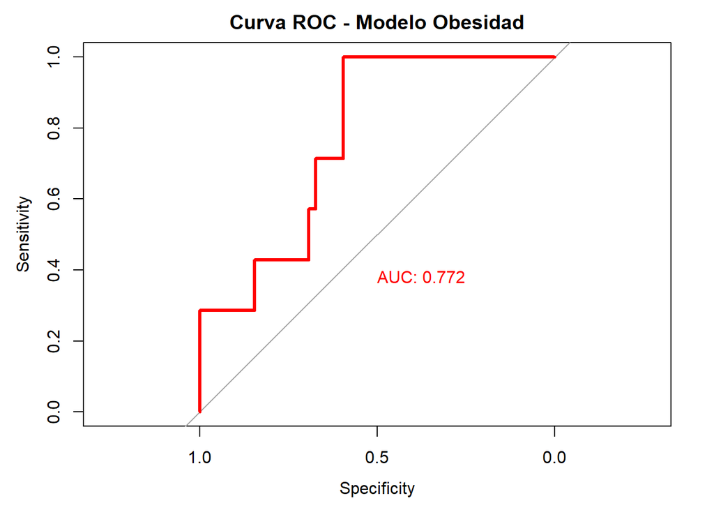

```r
# Grafico de la curva ROC
plot(curva_roc,
     main = "Curva ROC - Modelo Obesidad",
     col = "red",
     lwd = 3,
     print.auc = TRUE,
     print.auc.x = 0.5,         # Posición X del texto AUC
     print.auc.y = 0.4,         # Posición Y del texto AUC
     xlab = "Specificity",
     ylab = "Sensitivity"
     )
```